# R Notebook

```r
avg2020 <- mean(dfa1$`2020`,na.rm = TRUE)
dfa1 <- dfa1 %>%
mutate(
global_average=
  ifelse(
    dfa1$`2020` < avg2020
    ,1,0))
sum(dfa1$`global_average`,na.rm=TRUE)
```

```
[1] 70
```

```r
sum(dfa1$`global_average`,na.rm=TRUE)/length(dfa1$`global_average`)
```

```
[1] 0.2631579
```

From those nationsbelow the global average(2020), what is the average accesses of electricity coverage?

```r
dfa1_below <- dfa1 %>% filter(dfa1$`global_average`== 1)
mean(dfa1_below$`2020`,na.rm = TRUE)
```

```
[1] 52.29953
```

Wich are the top 10 nations with lowest % of electriciy coverage in 2020? What is the diference respect 2020?

```r
dfa1 <-dfa1 %>%
  mutate(
    difference_between_2020_2000 = dfa1$"2020" - dfa1$"2000"
  )
dfbottom = dfa1[order(dfa1$"2020", decreasing = FALSE), ] %>%
  select("Country Name", "2020","difference_between_2020_2000")
dfbottom %>% head(10)
```

| Country Name | 2020 | difference_between_2020_2000 |
| --- | --- | --- |
| South Sudan | 7.241338 | NA |
| Chad | 11.080117 | 7.900236 |
| Burundi | 11.735556 | 9.272319 |
| Malawi | 14.866769 | 10.066769 |
| Central African Republic | 15.465084 | 9.465084 |
| Burkina Faso | 18.957239 | 9.882219 |
| Congo, Dem. Rep. | 19.100000 | 12.400001 |
| Niger | 19.251909 | 12.770428 |
| Sierra Leone | 26.200886 | 18.412743 |
| Liberia | 27.534710 | NA |

Are there any nations wich had decrease it % of coverage between 2020-200? Which are they?

```r
dfa1 <-dfa1 %>%
  mutate(
    difference_between_2020_2000 = dfa1$"2020" - dfa1$"2000"
  )
dfa1 %>%
  arrange(difference_between_2020_2000) %>%
  select(`Country Name`, difference_between_2020_2000) %>%
  head(3)
```

| Country Name | difference_between_2020_2000 |
| --- | --- |
| Libya | -30.0926514 |
| Syrian Arab Republic | -4.3432693 |
| Bulgaria | -0.3000031 |

```r
NA
```

How many countries are over 95% of coverage? Wich % the total nations do they represent?

```r
## How many countries are over 95% of coverage? Wich %  the total nations do they represent?
## It´s impressive to see 65% of the nations are over 95%.
dftop <- dfa1 %>%
  filter(`2020` > 95) %>%
  nrow()
print(dftop)
```

```
[1] 175
```

```r
sum(dftop)/length(dfa1$"2020")
```

```
[1] 0.6578947
```

It´s impressive to see 65% of the nations are over 95%.

##MILESTONE2-B: In order to build interestenig table, We want to understand the second database in our database:

```r
summary(dfB)
```

```
 Country Code          Region          IncomeGroup        SpecialNotes        TableName
 Length:265         Length:265         Length:265         Length:265         Length:265
 Class :character   Class :character   Class :character   Class :character   Class :character
 Mode  :character   Mode  :character   Mode  :character   Mode  :character   Mode  :character
```

```r
unique(dfB$Region)
```

```
[1] "Latin America & Caribbean"  NA                           "South Asia"                 "Sub-Saharan Africa"         "Europe & Central Asia"
[6] "Middle East & North Africa" "East Asia & Pacific"        "North America"
```

```r
unique(dfB$IncomeGroup)
```

```
[1] "High income"         NA                    "Low income"          "Lower middle income" "Upper middle income"
```

```r
#We will leftjoin the dataset in order to ubnderstand the data by nation at a region and income level
dfull <- dfa1 %>%
  left_join(dfB,
            by = 'Country Code')
```

For the first table we want to se a summary of the general information by Region.

```r
library("kableExtra")
library("knitr")
RegionGroup <- dfull %>%
group_by(Region) %>%
  summarise(
    Total_Nations = length(`2020`),
    Mean_2020 = mean(`2020`,na.rm = TRUE),
    Mean_2010 = mean(`2010`,na.rm = TRUE),
    Mean_2000 = mean(`2000`,na.rm = TRUE),
    Below_Global_AVG = mean(`global_average`,na.rm = TRUE))%>%
  arrange(desc(Mean_2020),.by_group = FALSE)%>%
  filter(Region != "")
kable(RegionGroup,caption= "<ul>
                  Summary Statistics by Region:
                  <li>In 2020 they only region below 90% is Sub-Saharan Africa</li>
                  <li>All regions have improved trhough the years</li>
                  <li>Almost 90% of Sub-Saharan Africa are below global avg</li>") %>%
  kable_styling()
```

Summary Statistics by Region: In 2020 they only region below 90% is Sub-Saharan Africa All regions have improved trhough the years Almost 90% of Sub-Saharan Africa are below global avg

| Region | Total_Nations | Mean_2020 | Mean_2010 | Mean_2000 | Below_Global_AVG |
| --- | --- | --- | --- | --- | --- |
| North America | 3 | 100.00000 | 100.00000 | 100.00000 | 0.0000000 |
| Europe & Central Asia | 58 | 99.99053 | 99.93184 | 99.90177 | 0.0000000 |
| Latin America & Caribbean | 42 | 97.58716 | 93.63805 | 88.99815 | 0.0238095 |
| Middle East & North Africa | 21 | 94.95604 | 94.22746 | 92.98566 | 0.1428571 |
| South Asia | 8 | 94.77246 | 71.42097 | 47.11309 | 0.1250000 |
| East Asia & Pacific | 37 | 93.66514 | 82.21285 | 75.94505 | 0.1944444 |
| Sub-Saharan Africa | 48 | 51.51354 | 36.63577 | 27.70819 | 0.8958333 |

For the second table we want to se a summary of the general information by Income level.

```r
IncomeGroup <- dfull %>%
group_by(IncomeGroup) %>%
  summarise(
    Total_Nations = length(`2020`),
    Mean_2020 = mean(`2020`,na.rm = TRUE),
    Mean_2010 = mean(`2010`,na.rm = TRUE),
    Mean_2000 = mean(`2000`,na.rm = TRUE),
    Below_Global_AVG = mean(`global_average`,na.rm = TRUE))%>%
  arrange(desc(Mean_2020),.by_group = FALSE)%>%
  filter(IncomeGroup != "")
kable(IncomeGroup,caption= "<ul>
                  Summary Statistics by Income Group:
                  <li>In 2020 they Lower income levels are below 85%</li>
                  <li>All regions have improved trhough the years</li>
                  <li>More than 90% of Low Income level are below global avg</li>") %>%
  kable_styling()
```

Summary Statistics by Income Group: In 2020 they Lower income levels are below 85% All regions have improved trhough the years More than 90% of Low Income level are below global avg

| IncomeGroup | Total_Nations | Mean_2020 | Mean_2010 | Mean_2000 | Below_Global_AVG |
| --- | --- | --- | --- | --- | --- |
| High income | 80 | 99.95131 | 99.64945 | 99.24347 | 0.0000000 |
| Upper middle income | 54 | 96.43729 | 93.58422 | 88.75130 | 0.0961538 |
| Lower middle income | 54 | 82.38932 | 66.37793 | 54.27297 | 0.4444444 |
| Low income | 28 | 40.53946 | 24.34951 | 15.94527 | 0.9285714 |

##Milestone2C

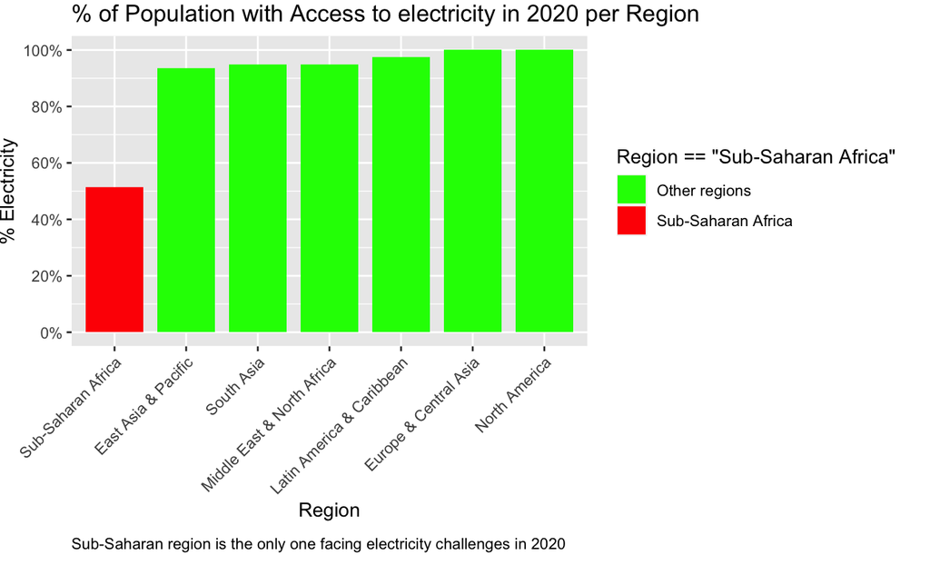

```r
RegionGroup <- RegionGroup %>% arrange(desc(Mean_2020))
ggplot(RegionGroup, aes(reorder((x = Region),Mean_2020), y = Mean_2020,fill = Region == "Sub-Saharan Africa", width = 0.8)) +
  geom_bar(stat = "identity") +
  scale_fill_manual(values = c("green", "red"),
                    breaks = c(FALSE, TRUE),
                    labels = c("Other regions", "Sub-Saharan Africa")) +
  labs(title = "% of Population with Access to electricity in 2020 per Region",
        x = "Region", y = "% Electricity", caption = "Sub-Saharan region is the only one facing electricity challenges in 2020") +
  theme(axis.text.x = element_text(angle = 45, hjust = 1),
         plot.margin = unit(c(0.1,0.5,0.1,0,1,0.1), "cm"),
         plot.caption = element_text(hjust = 0, margin = margin(10, 0, 10, 0))) +
  scale_y_continuous(limits = c(0, 100), breaks = seq(0, 100, by = 20), labels = paste0(seq(0, 100, by = 20), "%")) +
  guides(fill = guide_legend(override.aes = list(width = 0.8, size = 2)))
```

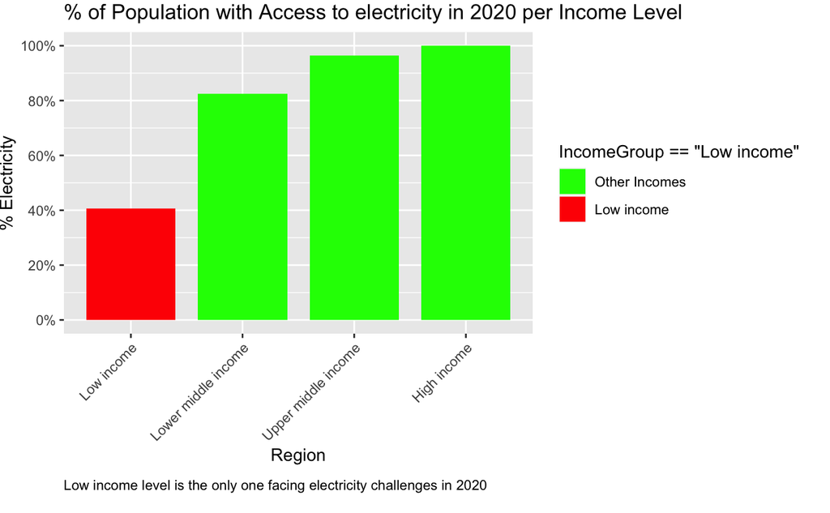

```r
RegionGroup <- RegionGroup %>% arrange(desc(Mean_2020))
ggplot(IncomeGroup, aes(reorder((x = IncomeGroup),Mean_2020), y = Mean_2020,fill = IncomeGroup == "Low income", width = 0.8)) +
  geom_bar(stat = "identity") +
  scale_fill_manual(values = c("green", "red"),
                    breaks = c(FALSE, TRUE),
                    labels = c("Other Incomes", "Low income")) +
  labs(title = "% of Population with Access to electricity in 2020 per Income Level",
        x = "Region", y = "% Electricity", caption = "Low income level is the only one facing electricity challenges in 2020") +
  theme(axis.text.x = element_text(angle = 45, hjust = 1),
         plot.margin = unit(c(0.1,0.5,0.1,0,1,0.1), "cm"),
         plot.caption = element_text(hjust = 0, margin = margin(10, 0, 10, 0))) +
  scale_y_continuous(limits = c(0, 100), breaks = seq(0, 100, by = 20), labels = paste0(seq(0, 100, by = 20), "%")) +
  guides(fill = guide_legend(override.aes = list(width = 0.8, size = 2)))
```

```r
NA
NA
```

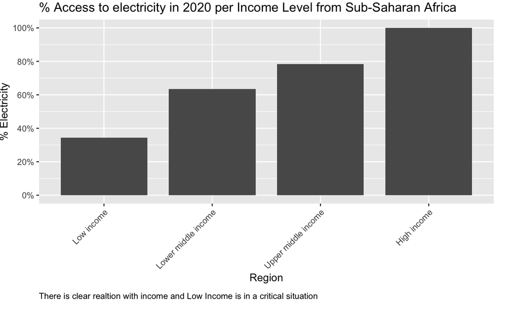

```r
ggplot(RegionGroupIncome, aes(reorder((x = IncomeGroup),Mean_2020), y = Mean_2020,width = 0.8)) +
  geom_bar(stat = "identity")  +
  labs(title = "% Access to electricity in 2020 per Income Level from Sub-Saharan Africa ",
        x = "Region", y = "% Electricity", caption = "There is clear realtion with income and Low Income is in a critical situation") +
  theme(axis.text.x = element_text(angle = 45, hjust = 1),
         plot.margin = unit(c(0.1,0.5,0.1,0,1,0.1), "cm"),
         plot.caption = element_text(hjust = 0, margin = margin(10, 0, 10, 0))) +
  scale_y_continuous(limits = c(0, 100), breaks = seq(0, 100, by = 20), labels = paste0(seq(0, 100, by = 20), "%")) +
  guides(fill = guide_legend(override.aes = list(width = 0.8, size = 2)))
```

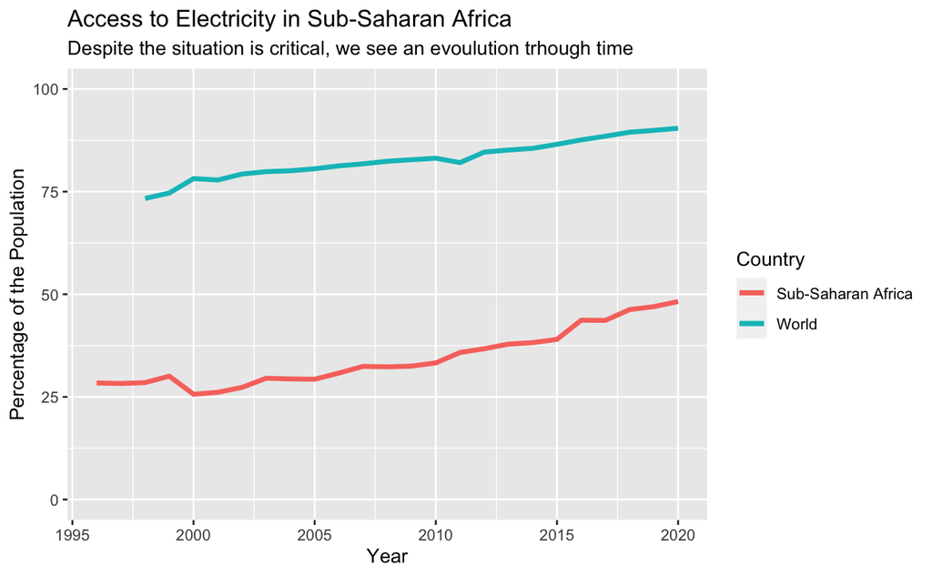

```r
dfa1_long <- dfa1_subset %>%
  pivot_longer(cols = -c("Country Name"), names_to = "Year", values_to = "Percentage")
dfa1_long$Year <- as.numeric(dfa1_long$Year)

dfa1_long <- dfa1_long %>% na.omit();
ggplot(dfa1_long[dfa1_long$`Country Name` == "Sub-Saharan Africa",],
       aes(
         x = Year,
         y = Percentage,
         color = "Sub-Saharan Africa",
         group = 1)) +
geom_line(linewidth = 1.3) +
geom_line(data = dfa1_long[dfa1_long$`Country Name` == "World",],
          aes(x = Year,
              y = Percentage,
              color = "World",
              group = 1),
          linewidth = 1.3) +
ggtitle("Access to Electricity in Sub-Saharan Africa") +
xlab("Year") +
ylab("Percentage of the Population") +
scale_y_continuous(limits = c(0, 100)) +

labs(subtitle = "Despite the situation is critical, we see an evoulution trhough time") +
guides(color = guide_legend(title = "Country"))
```